# Topic 25

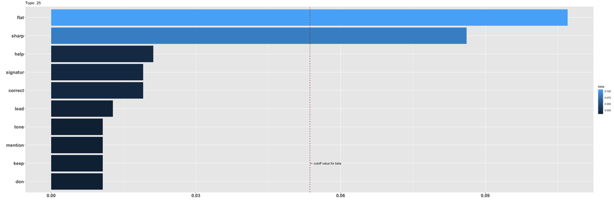

On interpreting beta: the term has a beta probability of being generated from the particular topic.

Values below are gamma : An estimated proportion of words from that document that are generated from that topic.

**Text Record Number: 1103** gamma: 30 % likelihood of this document (based on its words) in this topic

**C has no sharps or flats. RH 123 1234 123 12345  
LH 54321 3214321 321

G has an F sharp. RH 123 1234 123 12345  
LH 54321 3214321 321

D has two sharps in its key signature and they are F and C RH 123 1234 123 12345  
LH 54321 3214321 321

A has three sharps and they are F, C, and G RH 123 1234 123 12345  
LH 54321 3214321 321

E has four sharps and they are F, C, G, and D RH 123 1234 123 12345  
LH 54321 3214321 321

B has five sharps and they are F, C, G, D, A RH 123 1234 123 12345  
LH 43214321 321 4321

F has a B flat in its key signature RH 1234 123 1234 1234  
LH 54321 3214321 321

B flat has two flats and they are B and E RH 2123 1234 123 1234  
LH 3214321 321 43212

E flat has three flats and they are B, E, A RH 2 1234 123 1234 123  
LH 3214321 321 4321 2

A flat has four flats and they are B, E, A, D RH 23 123 1234 123123  
LH 3214321 321 4321 2

D flat has five flats and they are B, E, A, D, G RH 23 1234 123 123412  
LH 3214321 321 4321 2

G flat has six flats and they are B, E, A, D, G, C RH 234 123 1234 123 12 LH 4321321 4321 321 2**

**Text Record Number: 409** gamma: 30 % likelihood of this document (based on its words) in this topic

**I basically just count off against the memnomics below and it gets me there super fast.

Father Charles Goes Down And Ends Battle  
-> It’s the order of the sharps on the clef for the scales.  
-> It loops around on itself again  
-> Start a “Charles” because you know C has no sharps/flats, then go in order.  
Example:  
G is the first one after C, F is the first one in the list. Therefore 1 sharp = F#  
A is 3rd in the list, therefore 3 sharps. F#, C#, G#.  
Battle Ends And Down Goes Charles’ Father  
-> Shows us the order of the flat notes on the clef  
-> The keys are FBEAD (it spells BEAD, then just put an F in front of it)  
-–> These are all flats  
Example:  
F is first in FBEAD, therefore 1 flat = Bb (battle)  
Ab is 4th in FBEAD, therefore 4 flats = Bb, Eb, Ab, Db

** After writing this I realize it’s completely absurd but its still my thing.**

**Text Record Number: 267** gamma: 30 % likelihood of this document (based on its words) in this topic

**The one sharp on the F at the beginning of each line is the key signature (G major), which persists for the whole piece (or until a key change). So in every measure, F is sharp by default. Any other accidentals (like the E flat or C sharp) are reset at the beginning of each measure. The one E natural in the second measure of the second line is a “courtesy natural” which isn’t necessary to write in but helps you to avoid mis-reading the music.

Side comment: I see you’ve written in note letters. This is fine if you’re just starting off, but be careful not to let yourself use this as a crutch too much or it will hurt you in the long run!**

**Text Record Number: 815** gamma: 30 % likelihood of this document (based on its words) in this topic

**As long as the first one has a sharp or flat symbol, yes. You have to tell when you’re going back to the natural from a sharp or flat.**

**Text Record Number: 982** gamma: 30 % likelihood of this document (based on its words) in this topic

**I’m currently trying to apply my advice to piano students to myself to finally stick with a weight lifting program.

1. Not doing it to show off or be shredded, just want a healthy life habit.
2. less is more, tiny tiny tiny goals to avoid burnout and/or injury
3. being consistent even if it’s just once or twice a week
4. play the long game, don’t get caught up in the toxic thoughts of inadequacy. Instead of being worried about how good you are or aren’t from moment to moment, derive pleasure from knowing you will be doing this for a very long time.
5. NO SHORTCUTS, knowing is worthless compared to being able to actually apply a concept**

**Text Record Number: 592** gamma: 30 % likelihood of this document (based on its words) in this topic

*** Sight read a lot. * Learn music theory. Identify/play any triad or seventh chord by sight. Play a couple Hanon exercises slowly in all keys to develop awareness of the key signatures.? * You can’t sight read styles you don’t play well. * Look ahead, just like reading aloud. * Don’t stop for mistakes, but note the mistake and go back and re-practice it 4-5 times correctly. * Bach Chorales are often recommended for practice but they are bad. Why? Bach chorales contain 4 notes at a time, which are quite difficult for a newbie sight reader. They also have awkward passages that aren’t comfortable on the piano but work fine for voice. * What can you sight read and what do you want to sight read?**

**Text Record Number: 1035** gamma: 30 % likelihood of this document (based on its words) in this topic

**The only time this is the case is with a tied note. If a note was sharped in the previous bar and tied to the next bar… it’s still sharp… but only so long as it’s still tied.

If you have to re-articulate that same note, it will need another sharp to keep it sharp.**